# package-vignette

Package Purpose: The purpose of this package is to provide tools,functions, and visualizations for anyone interested in exploring health and fitness. How weight, calories, sleep, activities and their difficulty relate and impact each other.

```r
library(fitnessTracker)
data("dailyActivity")
data("dailySleep")
data("dailyWeightLog")
data("hourlyActivity")
data("weekDaily")
data("weightLog")

library(ggplot2)
library(ggthemes)
library(ggridges)
```

Data: The data included in this package is multiple files ranging in datasets about sleep, activity, and weight. This datasource was found from kaggle, overall already cleaned. The dataset was cleaned again to make it more user friendly for the use of this project/package.

dailyActivity: data containing activities, their intensity, and calories burned

```r
head(dailyActivity)
```

```
#>           Id ActivityDate TotalSteps TotalDistance DailyIntensity
#> 1 8053475328   2016-04-14      20159         15.97            560
#> 2 8053475328   2016-04-20      15108         12.19            435
#> 3 8053475328   2016-04-26      12685          9.62            399
#> 4 8053475328   2016-04-16      14549         11.11            383
#> 5 8053475328   2016-04-18      17076         12.66            513
#> 6 8053475328   2016-04-21      16057         12.51            482
#>   activity_duration intense_activity_duration idle_duration Calories
#> 1               317                       119          1123     3411
#> 2               252                        89           695     3043
#> 3               258                        68          1182     2846
#> 4               185                        96          1255     2867
#> 5               303                       102          1137     3133
#> 6               276                       100          1164     3103
#>   intensity_level
#> 1            High
#> 2            High
#> 3            High
#> 4            High
#> 5            High
#> 6            High
```

```r
summary(dailyActivity)
```

```
#>        Id            ActivityDate         TotalSteps    TotalDistance
#>  Min.   :1.504e+09   Length:800         Min.   :  746   Min.   : 0.500
#>  1st Qu.:2.320e+09   Class :character   1st Qu.: 5025   1st Qu.: 3.480
#>  Median :4.445e+09   Mode  :character   Median : 8027   Median : 5.570
#>  Mean   :4.754e+09                      Mean   : 8228   Mean   : 5.846
#>  3rd Qu.:6.962e+09                      3rd Qu.:10773   3rd Qu.: 7.753
#>  Max.   :8.878e+09                      Max.   :22988   Max.   :17.950
#>
#>  DailyIntensity  activity_duration intense_activity_duration idle_duration
#>  Min.   : 32.0   Min.   : 13.0     Min.   :  0.00            Min.   :  13.0
#>  1st Qu.:213.0   1st Qu.:191.8     1st Qu.:  0.00            1st Qu.: 720.0
#>  Median :316.0   Median :258.0     Median :  7.00            Median : 985.5
#>  Mean   :308.9   Mean   :253.1     Mean   : 20.52            Mean   : 944.9
#>  3rd Qu.:399.0   3rd Qu.:321.0     3rd Qu.: 32.00            3rd Qu.:1182.0
#>  Max.   :673.0   Max.   :540.0     Max.   :137.00            Max.   :1413.0
#>  NA's   :1
#>     Calories    intensity_level
#>  Min.   :  52   Length:800
#>  1st Qu.:1855   Class :character
#>  Median :2199   Mode  :character
#>  Mean   :2322
#>  3rd Qu.:2797
#>  Max.   :4236
#>
```

dailySleep: data containing sleep activity

```r
head(dailySleep)
```

```
#>           Id  SleepDate TotalSleepRecords TotalMinutesAsleep TotalTimeInBed
#> 1 1503960366 2016-04-12                 1                327            346
#> 2 1503960366 2016-04-15                 1                412            442
#> 3 1503960366 2016-04-17                 1                700            712
#> 4 1503960366 2016-04-19                 1                304            320
#> 5 1503960366 2016-04-20                 1                360            377
#> 6 1503960366 2016-04-21                 1                325            364
```

```r
summary(dailySleep)
```

```
#>        Id             SleepDate         TotalSleepRecords TotalMinutesAsleep
#>  Min.   :1.504e+09   Length:413         Min.   :1.000     Min.   : 58.0
#>  1st Qu.:3.977e+09   Class :character   1st Qu.:1.000     1st Qu.:361.0
#>  Median :4.703e+09   Mode  :character   Median :1.000     Median :433.0
#>  Mean   :5.001e+09                      Mean   :1.119     Mean   :419.5
#>  3rd Qu.:6.962e+09                      3rd Qu.:1.000     3rd Qu.:490.0
#>  Max.   :8.792e+09                      Max.   :3.000     Max.   :796.0
#>  TotalTimeInBed
#>  Min.   : 61.0
#>  1st Qu.:403.0
#>  Median :463.0
#>  Mean   :458.6
#>  3rd Qu.:526.0
#>  Max.   :961.0
```

dailyWeightLog: data containing weight changes over time

```r
head(dailyWeightLog)
```

```
#>           Id WeightDate WeightPounds   BMI
#> 1 4558609924 2016-04-18       153.66 27.25
#> 2 4558609924 2016-04-25       154.98 27.46
#> 3 4558609924 2016-05-01       154.10 27.32
#> 4 4558609924 2016-05-02       152.56 27.04
#> 5 4558609924 2016-05-09       152.34 27.00
#> 6 4319703577 2016-04-17       159.61 27.45
```

```r
summary(dailyWeightLog)
```

```
#>        Id             WeightDate         WeightPounds        BMI
#>  Min.   :1.504e+09   Length:67          Min.   :116.0   Min.   :21.45
#>  1st Qu.:6.962e+09   Class :character   1st Qu.:135.4   1st Qu.:23.96
#>  Median :6.962e+09   Mode  :character   Median :137.8   Median :24.39
#>  Mean   :7.009e+09                      Mean   :158.8   Mean   :25.19
#>  3rd Qu.:8.878e+09                      3rd Qu.:187.5   3rd Qu.:25.56
#>  Max.   :8.878e+09                      Max.   :294.3   Max.   :47.54
```

hourlyActivity: data containing activities by the hour

```r
head(hourlyActivity)
```

```
#>           Id            ActivityHour TotalSteps TotalIntensity Calories
#> 1 8053475328 2016-04-12 03:00:00 UTC          0              0       73
#> 2 8053475328 2016-04-12 04:00:00 UTC          0              0       73
#> 3 8053475328 2016-04-12 05:00:00 UTC          0              0       73
#> 4 8053475328 2016-04-12 06:00:00 UTC          0              0       73
#> 5 8053475328 2016-04-12 07:00:00 UTC          0              0       73
#> 6 8053475328 2016-04-12 08:00:00 UTC          0              0       73
#>   intensity_level
#> 1          Medium
#> 2          Medium
#> 3          Medium
#> 4          Medium
#> 5          Medium
#> 6          Medium
```

```r
summary(hourlyActivity)
```

```
#>        Id            ActivityHour         TotalSteps      TotalIntensity
#>  Min.   :1.504e+09   Length:22099       Min.   :    0.0   Min.   :  0.00
#>  1st Qu.:2.320e+09   Class :character   1st Qu.:    0.0   1st Qu.:  0.00
#>  Median :4.445e+09   Mode  :character   Median :   40.0   Median :  3.00
#>  Mean   :4.848e+09                      Mean   :  320.2   Mean   : 12.04
#>  3rd Qu.:6.962e+09                      3rd Qu.:  357.0   3rd Qu.: 16.00
#>  Max.   :8.878e+09                      Max.   :10554.0   Max.   :180.00
#>     Calories      intensity_level
#>  Min.   : 42.00   Length:22099
#>  1st Qu.: 63.00   Class :character
#>  Median : 83.00   Mode  :character
#>  Mean   : 97.39
#>  3rd Qu.:108.00
#>  Max.   :948.00
```

weekDaily: data containing activities by the week

```r
head(weekDaily)
```

```
#>   part_of_week day_of_week time_of_day total_steps averaage_steps
#> 1      Weekday      Monday     Morning      360899          11278
#> 2      Weekday      Monday   Afternoon      359198          11225
#> 3      Weekday      Monday     Evening      158351           4948
#> 4      Weekday      Monday       Night       44234           1382
#> 5      Weekday     Tuesday     Morning      453314          13737
#> 6      Weekday     Tuesday   Afternoon      467667          14172
#>   total_intensities average_intensities total_calories average_calories
#> 1             12977                 406          88355             2761
#> 2             13230                 413          81141             2536
#> 3              5819                 182          37844             1183
#> 4              2627                  82          70330             2198
#> 5             16090                 488         111380             3375
#> 6             16915                 513         103765             3144
#>   intensity_level
#> 1          Medium
#> 2          Medium
#> 3          Medium
#> 4             Low
#> 5            High
#> 6            High
```

```r
summary(weekDaily)
```

```
#>  part_of_week       day_of_week        time_of_day         total_steps
#>  Length:28          Length:28          Length:28          Min.   : 44234
#>  Class :character   Class :character   Class :character   1st Qu.:113100
#>  Mode  :character   Mode  :character   Mode  :character   Median :246118
#>                                                           Mean   :252691
#>                                                           3rd Qu.:368358
#>                                                           Max.   :493339
#>  averaage_steps  total_intensities average_intensities total_calories
#>  Min.   : 1382   Min.   : 2398     Min.   : 75.0       Min.   : 36403
#>  1st Qu.: 3513   1st Qu.: 4851     1st Qu.:151.0       1st Qu.: 64491
#>  Median : 7600   Median : 9208     Median :284.5       Median : 83542
#>  Mean   : 7756   Mean   : 9499     Mean   :291.6       Mean   : 76863
#>  3rd Qu.:11418   3rd Qu.:13764     3rd Qu.:422.5       3rd Qu.: 90995
#>  Max.   :14950   Max.   :17427     Max.   :528.0       Max.   :111380
#>  average_calories intensity_level
#>  Min.   :1138     Length:28
#>  1st Qu.:2004     Class :character
#>  Median :2578     Mode  :character
#>  Mean   :2359
#>  3rd Qu.:2770
#>  Max.   :3375
```

weightLog: data containing weight changes over including activities

```r
head(weightLog)
```

```
#>           Id weight_pounds BMI  body_type steps_count distance_measured
#> 1 2873212765           126  22     Normal        7556              5.10
#> 2 1503960366           116  23     Normal       12521              8.07
#> 3 6962181067           136  24     Normal        9795              6.59
#> 4 8877689391           188  25 Overweight       10657              8.09
#> 5 4558609924           154  27 Overweight        7685              5.08
#> 6 4319703577           160  27 Overweight        7769              5.23
#>   avg_intensities intense_activity_duration active_duration idle_duration
#> 1             359                        14             328          1097
#> 2             386                        40             287           828
#> 3             351                        23             287           662
#> 4             293                        28             233          1161
#> 5             343                        10             309          1094
#> 6             292                         4             271           715
#>   intensity_level
#> 1          Medium
#> 2          Medium
#> 3          Medium
#> 4          Medium
#> 5          Medium
#> 6          Medium
```

```r
summary(weightLog)
```

```
#>        Id            weight_pounds        BMI         body_type
#>  Min.   :1.504e+09   Min.   :116.0   Min.   :22.00   Length:8
#>  1st Qu.:2.637e+09   1st Qu.:133.5   1st Qu.:23.75   Class :character
#>  Median :4.439e+09   Median :157.0   Median :26.00   Mode  :character
#>  Mean   :4.575e+09   Mean   :171.8   Mean   :28.00
#>  3rd Qu.:5.923e+09   3rd Qu.:191.0   3rd Qu.:27.25
#>  Max.   :8.878e+09   Max.   :294.0   Max.   :48.00
#>   steps_count    distance_measured avg_intensities intense_activity_duration
#>  Min.   : 2235   Min.   :1.550     Min.   :103.0   Min.   : 3.00
#>  1st Qu.: 7478   1st Qu.:5.095     1st Qu.:292.8   1st Qu.: 8.50
#>  Median : 7727   Median :5.325     Median :347.0   Median :18.50
#>  Mean   : 8183   Mean   :5.641     Mean   :313.2   Mean   :22.88
#>  3rd Qu.:10010   3rd Qu.:6.960     3rd Qu.:364.0   3rd Qu.:31.00
#>  Max.   :12521   Max.   :8.090     Max.   :386.0   Max.   :61.00
#>  active_duration idle_duration    intensity_level
#>  Min.   : 95.0   Min.   : 662.0   Length:8
#>  1st Qu.:233.8   1st Qu.: 757.8   Class :character
#>  Median :279.0   Median : 961.0   Mode  :character
#>  Mean   :255.5   Mean   : 950.2
#>  3rd Qu.:292.5   3rd Qu.:1113.0
#>  Max.   :328.0   Max.   :1273.0
```

Functions: The functions included in this package cover data cleaning, analysis, and visualization. The data cleaning for this project is pre-done for this package and stores the usable files into the data folder.

Package File Function: displays raw files included in this package

```r
package_files()
```

```
#> [1] "dailyActivity_summary.csv"  "dailySleep_summary.csv"
#> [3] "dailyWeightLog_summary.csv" "hourlyActivity_summary.csv"
#> [5] "weekDaily_summary.csv"      "weightLog-report.csv"
```

BMR Function: calculates the Basal Metabolic Rate of a person based off their weight

```r
BMR(dailyWeightLog$WeightPounds)
```

```
#>  [1] 2034.72 2047.92 2039.12 2023.72 2021.52 2094.12 2091.92 1658.30 1658.30
#> [10] 2382.76 2382.76 2382.76 2382.76 2382.76 2389.36 2389.36 2373.74 2373.74
#> [19] 2380.34 2380.34 2380.34 2380.34 2371.76 2378.14 2378.14 2369.56 2369.56
#> [28] 2369.56 2369.56 2360.76 2360.76 2358.56 2349.76 1748.50 1761.70 2497.16
#> [37] 3439.64 1876.32 1867.52 1867.52 1874.12 1865.32 1849.70 1863.12 1863.12
#> [46] 1854.10 1854.10 1854.10 1854.10 1854.10 1845.30 1858.72 1858.72 1858.72
#> [55] 1858.72 1851.90 1851.90 1851.90 1851.90 1851.90 1843.10 1843.10 1847.50
#> [64] 1847.50 1847.50 1847.50 1847.50
```

TDEE Function: calculates Total Daily Energy Expenditure based on wweight and activity intensity level

```r
TDEE(weightLog$weight_pounds, weightLog$intensity_level)
```

```
#> [1] 2725.520 2570.706 2880.334 3685.435 3159.272 3252.024 3871.280 4467.528
```

Sleep Efficiency Function: calculates sleep effciency

```r
sleep_efficiency(dailySleep$TotalMinutesAsleep, dailySleep$TotalTimeInBed)
```

```
#>   [1]  94.51  93.21  98.31  95.00  95.49  89.29  94.01  95.77  85.76  89.42
#>  [11]  93.13  96.33  95.06  93.18  89.64  92.23  93.56  91.01  94.84  97.22
#>  [21]  98.83  95.04  93.14  93.70  87.32  82.83  88.96  67.01  75.13  61.39
#>  [31]  94.31  93.97  93.26  92.12  93.98  95.95  91.27  92.42  87.75  92.22
#>  [41]  90.39  92.80  95.41  94.22  93.91  95.29  93.21  94.13  96.08  94.40
#>  [51]  96.52  94.11  96.07  96.49  95.62  98.08  95.25  95.50  93.95  94.58
#>  [61]  94.02  88.41  87.95  91.00  89.68  92.36  89.77  90.47  95.04  87.85
#>  [71]  96.89  96.30  91.93  88.98  89.78  90.67  86.89  58.42  73.30  76.26
#>  [81]  55.49  67.31  55.44  64.84  74.58  63.17  58.94  56.10  67.39  64.63
#>  [91]  61.70  69.67  62.04  61.18  59.90  58.40  63.39  66.25  63.09  53.50
#> [101]  69.03  92.61 100.00  96.99  89.18  91.13  94.36  90.55  89.47  96.05
#> [111]  94.70  96.93  93.47  96.32  90.77  96.91  95.84  93.21  96.44  97.87
#> [121]  93.16  95.21  95.79  94.96  96.80  94.47  92.58  91.65  95.66  94.36
#> [131]  94.69  94.20  94.80  94.08  94.87  95.19  97.34  93.35  96.51  96.47
#> [141]  95.41  92.20  87.80  93.45  91.62  94.20  95.15  95.15  95.16  95.38
```

[output cut: 27 more lines]

Water Intake Function: calculates recommended water intake for activities in ounces

```r
water_intake(weightLog$weight_pounds, weightLog$intensity_level)
```

```
#> [1] 126 116 136 188 154 160 200 147
```

Step Vs. Calorie Visualization: shows relationship between steps and calories burned

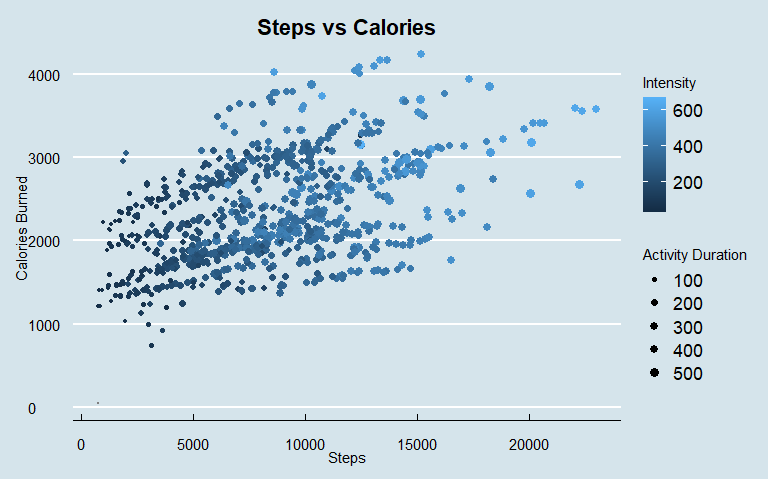

```r
steps_vs_calories(dailyActivity, "TotalSteps", "Calories", "DailyIntensity", "activity_duration")
```

Step Visualization:

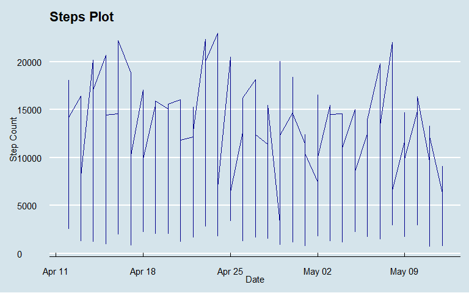

```r
steps_plot(dailyActivity, "ActivityDate", "TotalSteps")
```

Sleep Visualization

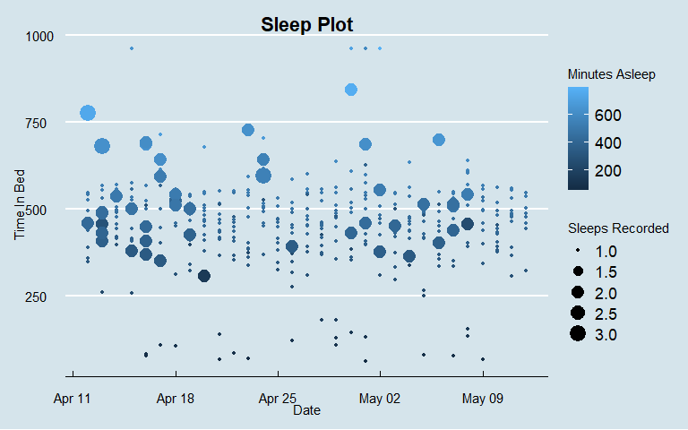

```r
sleep_plot(dailySleep, "SleepDate", "TotalTimeInBed", "TotalMinutesAsleep", "TotalSleepRecords")
```

Activity Intensity Visualization

```
#> Warning: Removed 1 row containing non-finite outside the scale range
#> (`stat_density_ridges()`).
```

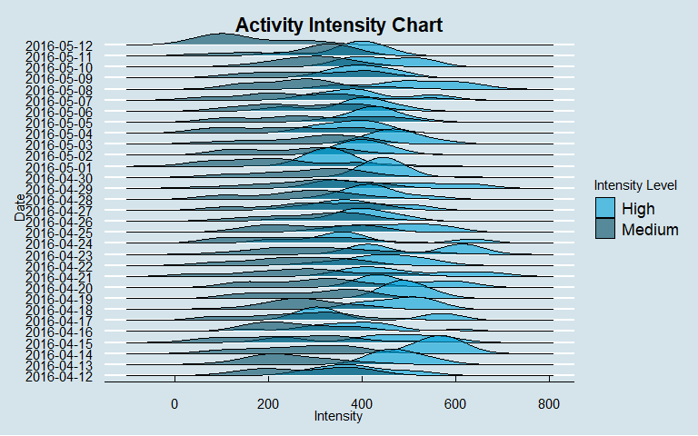

```r
intensity_plot(dailyActivity, "ActivityDate", "DailyIntensity", "intensity_level")
```

Summary: This package and its tools givers a beginner user friendly experience for data exploration and analysis for those interested in fitness and health. Enjoy!